# Lab 4: OLS, Regression Diagnostics, and Instrumental Variables

Author

Feng Qiu, Liyuan Xuan

Published

October 20, 2025

## 1 Preparation

### 1.1 Loading Packages

```r
library(stargazer)  # for better visualization of results
library(lmtest)     # statistical test for linear regression models
library(car)        # for diagnostics, such as vif
library(estimatr)   # for robust estimation
library(effects)    # to compute marginal effects
library(AER)        # for IV regression

# library(Ecdat)    # the dataset "Males" and "Schooling" is also available online from package "Ecdat"
```

### 1.2 Read in External Data

```r
setwd("D:/Dropbox/Teaching/AREC513/Fall2025/materials/data")
males <- read.csv(file = "ch3_data_csv/males1987_updated.csv") # make sure you are in the correct working directory
head(males)
```

| X | BLACK | EXPER | HISP | HOURS | MAR | SCHOOL | UNION | LOGWAGE | EXPER2 |
| --- | --- | --- | --- | --- | --- | --- | --- | --- | --- |
| 1 | 0 | 8 | 0 | 50.76923 | 0 | 14 | 0 | 1.669188 | 64 |
| 2 | 0 | 11 | 0 | 47.61538 | 0 | 13 | 0 | 1.820334 | 121 |
| 3 | 0 | 11 | 0 | 45.00000 | 1 | 12 | 0 | 2.873161 | 121 |
| 4 | 0 | 9 | 0 | 55.00000 | 1 | 12 | 0 | 2.135689 | 81 |
| 5 | 0 | 12 | 0 | 40.00000 | 1 | 12 | 0 | 2.112393 | 144 |
| 6 | 0 | 9 | 0 | 68.61539 | 0 | 10 | 0 | 2.148120 | 81 |

```r
# change variable names to lowercase
names(males) <- tolower(names(males))
head(males)
```

| x | black | exper | hisp | hours | mar | school | union | logwage | exper2 |
| --- | --- | --- | --- | --- | --- | --- | --- | --- | --- |
| 1 | 0 | 8 | 0 | 50.76923 | 0 | 14 | 0 | 1.669188 | 64 |
| 2 | 0 | 11 | 0 | 47.61538 | 0 | 13 | 0 | 1.820334 | 121 |
| 3 | 0 | 11 | 0 | 45.00000 | 1 | 12 | 0 | 2.873161 | 121 |
| 4 | 0 | 9 | 0 | 55.00000 | 1 | 12 | 0 | 2.135689 | 81 |
| 5 | 0 | 12 | 0 | 40.00000 | 1 | 12 | 0 | 2.112393 | 144 |
| 6 | 0 | 9 | 0 | 68.61539 | 0 | 10 | 0 | 2.148120 | 81 |

## 2 Model Estimation

### 2.1 Model Specification: Linear vs. Quadratic

```r
eq.a <- logwage ~ school + exper + union + mar + black + hisp
eq.b <- logwage ~ school + exper +I(exper^2) + union + mar + black+ hisp

mod.a <- lm(eq.a, data = males)
mod.b <- lm(eq.b, data = males)

stargazer(mod.a, mod.b,
          type = "text",
          digits = 3,
          title = "Model comparison: linear vs. quadratic",
          intercept.bottom=FALSE,
          dep.var.caption="Dependent variable: log(wage)",
          dep.var.labels.include = FALSE,
          model.numbers = FALSE,
          column.labels=c("Linear", "Quadratic"),
          no.space = TRUE
          )
```

```
Model comparison: linear vs. quadratic
===================================================================
                             Dependent variable: log(wage)
                    -----------------------------------------------
                            Linear                 Quadratic
-------------------------------------------------------------------
Constant                   0.776***                1.892***
                            (0.261)                 (0.509)
school                     0.088***                0.095***
                            (0.013)                 (0.013)
exper                       -0.002                 -0.225**
                            (0.014)                 (0.089)
I(exper2)                                           0.010**
                                                    (0.004)
union                      0.117***                0.129***
                            (0.043)                 (0.043)
mar                         0.091**                 0.091**
                            (0.039)                 (0.039)
black                      -0.198***               -0.194***
                            (0.061)                 (0.061)
hisp                         0.043                   0.033
                            (0.053)                 (0.053)
-------------------------------------------------------------------
Observations                  545                     545
R2                           0.155                   0.165
Adjusted R2                  0.145                   0.154
Residual Std. Error    0.432 (df = 538)        0.429 (df = 537)
F Statistic         16.437*** (df = 6; 538) 15.163*** (df = 7; 537)
===================================================================
Note:                                   *p<0.1; **p<0.05; ***p<0.01
```

**Note**

Sometimes we are not only interested in the effects of an explanatory variable on our dependent variable, but also if such effects vary as the level of this explanatory variable changes. Using the regression above as an example, try to take the derivative of “wage(log)” with respect to “exper”.

### 2.2 Marginal effects

Visualize the marginal effects of our explanatory variables, we can combine `plot()` with `effect()` from the package “effects”.

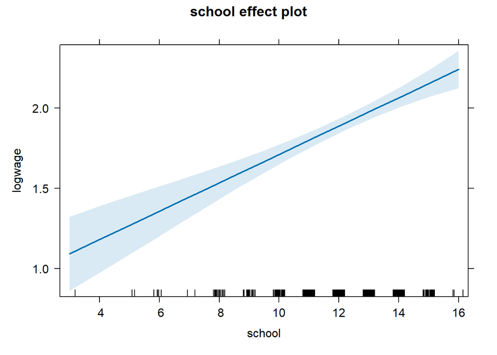

```r
plot(effect("school", mod.a))
```

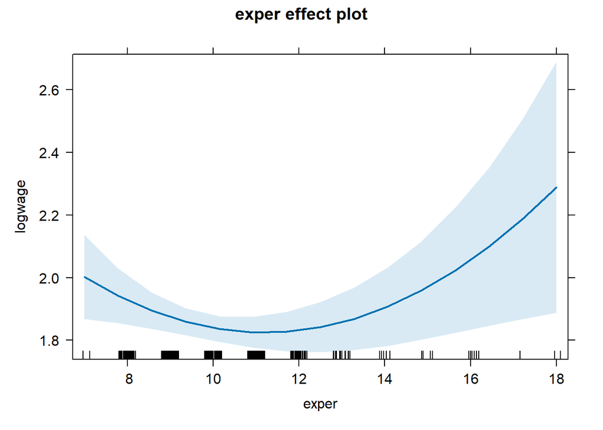

```r
plot(effect("exper", mod.b))
```

### 2.3 Subsample Analysis

To estimate the same regression on a subsample of our data, we can utilize the `subset` argument of function `lm()`.

```r
# Estimate separate model for unionized (union == 1) and non-unionized workers (union == 0)

eq.c <- logwage ~ school + exper + mar + black + hisp

mod.d <- lm(eq.c, data = males, subset = (union == 1))
mod.e <- lm(eq.c, data = males, subset = (union == 0))

stargazer(mod.d, mod.e,
          type = "text",
          digits = 3,
          title = "Union impacts",
          intercept.bottom = FALSE,
          dep.var.caption = "Dependent variable: log(wage)",
          dep.var.labels.include = FALSE,
          model.numbers = FALSE,
          column.labels = c("Union", "Non-union"),
          no.space = TRUE
          )
```

```
Union impacts
================================================================
                           Dependent variable: log(wage)
                    --------------------------------------------
                           Union                Non-union
----------------------------------------------------------------
Constant                  1.123**                0.724**
                          (0.503)                (0.308)
school                    0.066**               0.092***
                          (0.029)                (0.015)
exper                      0.003                 -0.001
                          (0.026)                (0.016)
mar                        0.027                 0.107**
                          (0.073)                (0.046)
black                      -0.130               -0.264***
                          (0.087)                (0.084)
hisp                       0.096                  0.029
                          (0.095)                (0.064)
----------------------------------------------------------------
Observations                143                    402
R2                         0.073                  0.176
Adjusted R2                0.039                  0.165
Residual Std. Error   0.403 (df = 137)      0.442 (df = 396)
F Statistic         2.147* (df = 5; 137) 16.875*** (df = 5; 396)
================================================================
Note:                                *p<0.1; **p<0.05; ***p<0.01
```

```r
# Estimate model for non-unionized (union == 0) and married workers (mar == 1)
mod.f <- lm(eq.a, data = males, subset=(union == 0 & mar == 1))

stargazer(mod.d, mod.e, mod.f,
          type = "text",
          digits = 3,
          title = "Union impacts",
          intercept.bottom = FALSE,
          dep.var.caption = "Dependent variable: log(wage)",
          dep.var.labels.include = FALSE,
          model.numbers = FALSE,
          column.labels = c("Union", "Non-union", "Non-union and Married"),
          no.space = TRUE
          )
```

```
Union impacts
========================================================================================
                                       Dependent variable: log(wage)
                    --------------------------------------------------------------------
                           Union                Non-union         Non-union and Married
----------------------------------------------------------------------------------------
Constant                  1.123**                0.724**                 0.844**
                          (0.503)                (0.308)                 (0.386)
school                    0.066**               0.092***                0.095***
                          (0.029)                (0.015)                 (0.019)
exper                      0.003                 -0.001                  -0.006
                          (0.026)                (0.016)                 (0.021)
union

mar                        0.027                 0.107**
                          (0.073)                (0.046)
black                      -0.130               -0.264***                -0.246*
                          (0.087)                (0.084)                 (0.133)
hisp                       0.096                  0.029                   0.046
                          (0.095)                (0.064)                 (0.084)
----------------------------------------------------------------------------------------
Observations                143                    402                     243
R2                         0.073                  0.176                   0.170
Adjusted R2                0.039                  0.165                   0.156
Residual Std. Error   0.403 (df = 137)      0.442 (df = 396)        0.425 (df = 238)
F Statistic         2.147* (df = 5; 137) 16.875*** (df = 5; 396) 12.216*** (df = 4; 238)
========================================================================================
Note:                                                        *p<0.1; **p<0.05; ***p<0.01
```

## 3 Multicollinearity Diagnostics

Recall that multicollinearity means there is an exact or approximate linear relationship existing between the explanatory variables. To detect whether you have multicollinearity, we can calculate the Variance Inflation Factors (VIF) for our linear models using function `vif()` from the package “car”.

```r
vif(mod.a)
```

```
  school    exper    union      mar    black     hisp
1.555705 1.519834 1.044158 1.047135 1.112910 1.081147
```

**Tip**

In general, a VIF above 10 may indicate a problem of multicollinearity, but it’s still up to you to determine whether dropping explanatory variable(s) is necessary depending on what story you are trying to tell with your model.

Unless you are having perfect/exact multicollinearity, in this case, dropping variable(s) that is perfectly collinear with your current explanatory variables becomes necessary. Most of functions in R will automatically omit these variables during estimation.

## 4 Heteroskedasticity: Diagnostics and Solutions

One of the key assumptions of linear regression is that the variance of error terms are constant across all levels of the independent variables (also known as homoscedasticity). When this assumption is violated, heteroscedasticity is present in your regression.

### 4.1 Breusch-Pagan Test

A formal test to detect whether heteroscedasticity is present is called the Breusch-Pagan test:

$$H_0:Var(\epsilon_i)=\sigma^2$$
$$H_1:Var(\epsilon_i) \neq \sigma^2$$

```r
bptest(mod.a)
```

```
    studentized Breusch-Pagan test

data:  mod.a
BP = 9.4177, df = 6, p-value = 0.1514
```

```r
# check p-value or compare the test statistics against the critical value
# qchisq(0.95, 6) => 12.59
```

Or you can manually estimate the following regression to see if the variance of the error term is a function of your Xs.

```r
summary(lm(resid(mod.a)^2 ~ school + exper + union + mar + black + hisp,
           data = males)
        )
```

```
Call:
lm(formula = resid(mod.a)^2 ~ school + exper + union + mar +
    black + hisp, data = males)

Residuals:
     Min       1Q   Median       3Q      Max
-0.28065 -0.15978 -0.09612  0.04232  2.84332

Coefficients:
             Estimate Std. Error t value Pr(>|t|)
(Intercept)  0.369663   0.190523   1.940   0.0529 .
school      -0.000427   0.009631  -0.044   0.9647
exper       -0.015196   0.010052  -1.512   0.1312
union       -0.037403   0.031315  -1.194   0.2328
mar         -0.048209   0.028348  -1.701   0.0896 .
black        0.042671   0.044482   0.959   0.3378
hisp         0.038111   0.038637   0.986   0.3244
---
Signif. codes:  0 '***' 0.001 '**' 0.01 '*' 0.05 '.' 0.1 ' ' 1

Residual standard error: 0.3147 on 538 degrees of freedom
Multiple R-squared:  0.01728,   Adjusted R-squared:  0.006321
F-statistic: 1.577 on 6 and 538 DF,  p-value: 0.1517
```

### 4.2 Robust Standard Errors

One way to deal with heteroskedasticity is to compute heteroskedasticity-robust standard errors for results reporting, hypothesis testing, and forecasting, while keeping your OLS estimator unchanged. To calculate the heteroskedasticity-robust standard errors and use it to perform t-test on your estimators:

```r
summary(mod.a)
```

```
Call:
lm(formula = eq.a, data = males)

Residuals:
     Min       1Q   Median       3Q      Max
-1.74986 -0.27455  0.02351  0.28484  1.52273

Coefficients:
             Estimate Std. Error t value Pr(>|t|)
(Intercept)  0.775597   0.261259   2.969  0.00312 **
school       0.088346   0.013207   6.689 5.63e-11 ***
exper       -0.001914   0.013785  -0.139  0.88965
union        0.117368   0.042941   2.733  0.00648 **
mar          0.091047   0.038872   2.342  0.01953 *
black       -0.198431   0.060997  -3.253  0.00121 **
hisp         0.042725   0.052982   0.806  0.42036
---
Signif. codes:  0 '***' 0.001 '**' 0.01 '*' 0.05 '.' 0.1 ' ' 1

Residual standard error: 0.4316 on 538 degrees of freedom
Multiple R-squared:  0.1549,    Adjusted R-squared:  0.1455
F-statistic: 16.44 on 6 and 538 DF,  p-value: < 2.2e-16
```

```r
coeftest(mod.a)
```

```
t test of coefficients:

              Estimate Std. Error t value  Pr(>|t|)
(Intercept)  0.7755970  0.2612595  2.9687  0.003124 **
school       0.0883456  0.0132069  6.6894 5.632e-11 ***
exper       -0.0019136  0.0137846 -0.1388  0.889646
union        0.1173682  0.0429412  2.7332  0.006478 **
mar          0.0910467  0.0388724  2.3422  0.019534 *
black       -0.1984314  0.0609969 -3.2531  0.001213 **
hisp         0.0427252  0.0529817  0.8064  0.420360
---
Signif. codes:  0 '***' 0.001 '**' 0.01 '*' 0.05 '.' 0.1 ' ' 1
```

```r
coeftest(mod.a, vcov = hccm(mod.a, type = "hc0"))
```

```
t test of coefficients:

              Estimate Std. Error t value  Pr(>|t|)
(Intercept)  0.7755970  0.2575339  3.0116  0.002721 **
school       0.0883456  0.0130117  6.7897 2.979e-11 ***
exper       -0.0019136  0.0127703 -0.1498  0.880943
union        0.1173682  0.0403244  2.9106  0.003757 **
mar          0.0910467  0.0398964  2.2821  0.022874 *
black       -0.1984314  0.0634336 -3.1282  0.001854 **
hisp         0.0427252  0.0560931  0.7617  0.446583
---
Signif. codes:  0 '***' 0.001 '**' 0.01 '*' 0.05 '.' 0.1 ' ' 1
```

```r
coeftest(mod.a, vcov = hccm(mod.a, type = "hc3"))
```

```
t test of coefficients:

              Estimate Std. Error t value  Pr(>|t|)
(Intercept)  0.7755970  0.2613007  2.9682  0.003129 **
school       0.0883456  0.0132325  6.6764 6.111e-11 ***
exper       -0.0019136  0.0129939 -0.1473  0.882978
union        0.1173682  0.0409838  2.8638  0.004350 **
mar          0.0910467  0.0404455  2.2511  0.024782 *
black       -0.1984314  0.0648538 -3.0597  0.002326 **
hisp         0.0427252  0.0571166  0.7480  0.454766
---
Signif. codes:  0 '***' 0.001 '**' 0.01 '*' 0.05 '.' 0.1 ' ' 1
```

**Note**

There are five options for the `type` argument in the function `hccm()` for computing the heteroscedasticity-corrected covariance matrices for inference. They are “hc0”, “hc1”, “hc2”, “hc3” (default), and “hc4”. For details regarding these 5 options, check the RDocumentation of “hccm()”.

- “hc0” calculates the classic White covariance matrix.
- “hc1”, “hc2”, and “hc3” calculate the refined White covariance matrix. “hc3” is the default option that works better if you have a small sample size.
- “hc4” is useful if you have outliers.

Alternatively, you can directly estimate the regression with heteroskedasticity-robust standard errors, using function `lm_robust()` from the package “estimatr”.

```r
mod.h <- lm_robust(eq.a, data = males, se_type = "HC3")
summary(mod.h)
```

```
Call:
lm_robust(formula = eq.a, data = males, se_type = "HC3")

Standard error type:  HC3

Coefficients:
             Estimate Std. Error t value  Pr(>|t|) CI Lower CI Upper  DF
(Intercept)  0.775597    0.26130  2.9682 3.129e-03  0.26230  1.28889 538
school       0.088346    0.01323  6.6764 6.111e-11  0.06235  0.11434 538
exper       -0.001914    0.01299 -0.1473 8.830e-01 -0.02744  0.02361 538
union        0.117368    0.04098  2.8638 4.350e-03  0.03686  0.19788 538
mar          0.091047    0.04045  2.2511 2.478e-02  0.01160  0.17050 538
black       -0.198431    0.06485 -3.0597 2.326e-03 -0.32583 -0.07103 538
hisp         0.042725    0.05712  0.7480 4.548e-01 -0.06947  0.15492 538

Multiple R-squared:  0.1549 ,   Adjusted R-squared:  0.1455
F-statistic: 16.82 on 6 and 538 DF,  p-value: < 2.2e-16
```

```r
coeftest(mod.a, vcov = hccm(mod.a, type = "hc3"))
```

```
t test of coefficients:

              Estimate Std. Error t value  Pr(>|t|)
(Intercept)  0.7755970  0.2613007  2.9682  0.003129 **
school       0.0883456  0.0132325  6.6764 6.111e-11 ***
exper       -0.0019136  0.0129939 -0.1473  0.882978
union        0.1173682  0.0409838  2.8638  0.004350 **
mar          0.0910467  0.0404455  2.2511  0.024782 *
black       -0.1984314  0.0648538 -3.0597  0.002326 **
hisp         0.0427252  0.0571166  0.7480  0.454766
---
Signif. codes:  0 '***' 0.001 '**' 0.01 '*' 0.05 '.' 0.1 ' ' 1
```

### 4.3 Weighted Least Squares (WLS)

Recall that heteroskedasticity means the variance of the error terms depends on the values of one or more explanatory variables, for example, with a multiplicative heteroskedasticity specification,

$$Var(\epsilon_i)=\sigma_i^2=\sigma^2 h_i^2$$
Then you can transform your regression to ensure homoskedasticity with the weight $\frac{1}{h_i}$, like

$$\frac{y_i}{h_i} = \frac{x_i}{h_i}\beta + \frac{\epsilon_i}{h_i}$$

Now, suppose our model “eq.a” exhibits heteroskedasticity such that

$$Var(\epsilon_i)=\sigma^2 \times \text{school}_i^2$$

```r
w <- 1 / males$school
mod.g <- lm(eq.a, weight = w, data = males)
summary(mod.g)
```

```
Call:
lm(formula = eq.a, data = males, weights = w)

Weighted Residuals:
     Min       1Q   Median       3Q      Max
-0.55885 -0.07816  0.00643  0.08311  0.44299

Coefficients:
             Estimate Std. Error t value Pr(>|t|)
(Intercept)  0.858927   0.254177   3.379 0.000780 ***
school       0.076516   0.012729   6.011  3.4e-09 ***
exper        0.003937   0.012968   0.304 0.761525
union        0.121443   0.042942   2.828 0.004857 **
mar          0.086543   0.038565   2.244 0.025235 *
black       -0.208662   0.060614  -3.442 0.000621 ***
hisp         0.043733   0.051215   0.854 0.393541
---
Signif. codes:  0 '***' 0.001 '**' 0.01 '*' 0.05 '.' 0.1 ' ' 1

Residual standard error: 0.1268 on 538 degrees of freedom
Multiple R-squared:  0.1464,    Adjusted R-squared:  0.1369
F-statistic: 15.38 on 6 and 538 DF,  p-value: 2.65e-16
```

```r
stargazer(mod.a, mod.g,
          type = "text",
          digits = 3,
          title = "OLS vs. WLS",
          intercept.bottom = FALSE,
          dep.var.caption = "Dependent variable: log(wage)",
          dep.var.labels.include = FALSE,
          model.numbers = FALSE,
          column.labels = c("OLS", "WLS"),
          no.space = TRUE
          )
```

```
OLS vs. WLS
=============================================================
                               Dependent variable: log(wage)
                               ------------------------------
                                     OLS            WLS
-------------------------------------------------------------
Constant                          0.776***        0.859***
                                   (0.261)        (0.254)
school                            0.088***        0.077***
                                   (0.013)        (0.013)
exper                              -0.002          0.004
                                   (0.014)        (0.013)
union                             0.117***        0.121***
                                   (0.043)        (0.043)
mar                                0.091**        0.087**
                                   (0.039)        (0.039)
black                             -0.198***      -0.209***
                                   (0.061)        (0.061)
hisp                                0.043          0.044
                                   (0.053)        (0.051)
-------------------------------------------------------------
Observations                         545            545
R2                                  0.155          0.146
Adjusted R2                         0.145          0.137
Residual Std. Error (df = 538)      0.432          0.127
F Statistic (df = 6; 538)         16.437***      15.376***
=============================================================
Note:                             *p<0.1; **p<0.05; ***p<0.01
```

## 5 Endogeneity and Instrumental Variables

### 5.1 Estimation

For the illustration of this section, let’s load in a new dataset “school” and estimate a linear regression “mod.e1”.

```r
setwd("D:/Dropbox/Teaching/AREC513/Fall2025/materials/data")
school <- read.csv(file = "ch5_data_csv/schooling.csv")

school <- school[, c("black", "smsa76", "south76", "age76", "ed76", "daded", "momed", "wage76")]
head(school)
```

| black | smsa76 | south76 | age76 | ed76 | daded | momed | wage76 |
| --- | --- | --- | --- | --- | --- | --- | --- |
| 1 | 1 | 0 | 29 | 7 | 9.94 | 10.25 | 548 |
| 0 | 1 | 0 | 27 | 12 | 8.00 | 8.00 | 481 |
| 0 | 1 | 0 | 34 | 12 | 14.00 | 12.00 | 721 |
| 0 | 1 | 0 | 27 | 11 | 11.00 | 12.00 | 250 |
| 0 | 1 | 0 | 34 | 12 | 8.00 | 7.00 | 729 |
| 0 | 1 | 0 | 26 | 12 | 9.00 | 12.00 | 500 |

```r
eq.wage <- log(wage76) ~ ed76 + age76 + black + smsa76 + south76
mod.e1 <- lm(eq.wage, data = school)
summary(mod.e1)
```

```
Call:
lm(formula = eq.wage, data = school)

Residuals:
     Min       1Q   Median       3Q      Max
-1.69292 -0.23227  0.02205  0.24880  1.31507

Coefficients:
             Estimate Std. Error t value Pr(>|t|)
(Intercept)  4.677451   0.073952  63.250   <2e-16 ***
ed76         0.034494   0.002726  12.655   <2e-16 ***
age76        0.039313   0.002196  17.906   <2e-16 ***
black       -0.188223   0.017768 -10.593   <2e-16 ***
smsa76       0.164741   0.015692  10.499   <2e-16 ***
south76     -0.129053   0.015229  -8.474   <2e-16 ***
---
Signif. codes:  0 '***' 0.001 '**' 0.01 '*' 0.05 '.' 0.1 ' ' 1

Residual standard error: 0.3772 on 3004 degrees of freedom
Multiple R-squared:  0.2788,    Adjusted R-squared:  0.2776
F-statistic: 232.2 on 5 and 3004 DF,  p-value: < 2.2e-16
```

Since an individual’s education level may be endogenous when using it to explain his/her wages, the use of Instrumental Variables (IV) can provide a solution. Let’s first use “daded”, dad’s education, to estimate an instrumental-variable regression using `ivreg()`

```r
mod.iv <- ivreg(log(wage76) ~
                ed76 + age76 + black + smsa76 + south76 |
                       age76 + black + smsa76 + south76 + daded,
                data = school)
summary(mod.iv)
```

```
Call:
ivreg(formula = log(wage76) ~ ed76 + age76 + black + smsa76 +
    south76 | age76 + black + smsa76 + south76 + daded, data = school)

Residuals:
     Min       1Q   Median       3Q      Max
-1.69293 -0.23228  0.02203  0.24880  1.31505

Coefficients:
             Estimate Std. Error t value Pr(>|t|)
(Intercept)  4.677386   0.125691  37.213  < 2e-16 ***
ed76         0.034498   0.007967   4.330 1.54e-05 ***
age76        0.039313   0.002199  17.880  < 2e-16 ***
black       -0.188215   0.020907  -9.003  < 2e-16 ***
smsa76       0.164737   0.017246   9.552  < 2e-16 ***
south76     -0.129050   0.015692  -8.224 2.89e-16 ***
---
Signif. codes:  0 '***' 0.001 '**' 0.01 '*' 0.05 '.' 0.1 ' ' 1

Residual standard error: 0.3772 on 3004 degrees of freedom
Multiple R-Squared: 0.2788, Adjusted R-squared: 0.2776
Wald test: 203.9 on 5 and 3004 DF,  p-value: < 2.2e-16
```

Alternatively, you can build a two-stage regression, that,

- Stage 1: acquire the fitted value of the endogenous variable $X_i$, by regressing it on the instrument $Z_i$ and covariates $H_i$.
  $$X_i=\alpha_0+\alpha_1Z_i+\alpha_2H_i+v_i$$
- Stage 2: regress $Y_i$ on the fitted variable ($\hat{X_i}$) and covariates $H_i$.
  $$Y_i=\beta_0+\beta_1\hat{X_i}+\beta_2H_i+\epsilon_i$$

```r
# stage 1
mod.s1 <- lm(ed76 ~ age76 + black + smsa76 + south76 + daded,
             data = school)
# stage 2
ed76.hat <- mod.s1$fitted.values
mod.s2 <- lm(log(wage76) ~ ed76.hat + age76 + black + smsa76 + south76,
             data = school)
summary(mod.s2)
```

```
Call:
lm(formula = log(wage76) ~ ed76.hat + age76 + black + smsa76 +
    south76, data = school)

Residuals:
     Min       1Q   Median       3Q      Max
-1.64101 -0.23973  0.01857  0.25472  1.40168

Coefficients:
             Estimate Std. Error t value Pr(>|t|)
(Intercept)  4.677386   0.128615  36.367  < 2e-16 ***
ed76.hat     0.034498   0.008152   4.232 2.39e-05 ***
age76        0.039313   0.002250  17.473  < 2e-16 ***
black       -0.188215   0.021393  -8.798  < 2e-16 ***
smsa76       0.164737   0.017647   9.335  < 2e-16 ***
south76     -0.129050   0.016057  -8.037 1.31e-15 ***
---
Signif. codes:  0 '***' 0.001 '**' 0.01 '*' 0.05 '.' 0.1 ' ' 1

Residual standard error: 0.386 on 3004 degrees of freedom
Multiple R-squared:  0.2448,    Adjusted R-squared:  0.2436
F-statistic: 194.8 on 5 and 3004 DF,  p-value: < 2.2e-16
```

```r
stargazer(mod.iv, mod.s2,
          type = "text",
          digits = 4,
          title = "IV vs. 2SLS",
          intercept.bottom = FALSE,
          dep.var.caption = "Dependent variable: log(wage)",
          dep.var.labels.include = FALSE,
          model.numbers = FALSE,
          column.labels = c("IV", "2SLS"),
          no.space = TRUE
          )
```

```
IV vs. 2SLS
=======================================================================
                                     Dependent variable: log(wage)
                                ---------------------------------------
                                instrumental            OLS
                                  variable
                                     IV                 2SLS
-----------------------------------------------------------------------
Constant                         4.6774***           4.6774***
                                  (0.1257)            (0.1286)
ed76                             0.0345***
                                  (0.0080)
ed76.hat                                             0.0345***
                                                      (0.0082)
age76                            0.0393***           0.0393***
                                  (0.0022)            (0.0022)
black                            -0.1882***          -0.1882***
                                  (0.0209)            (0.0214)
smsa76                           0.1647***           0.1647***
                                  (0.0172)            (0.0176)
south76                          -0.1291***          -0.1291***
                                  (0.0157)            (0.0161)
-----------------------------------------------------------------------
Observations                       3,010               3,010
R2                                 0.2788              0.2448
Adjusted R2                        0.2776              0.2436
Residual Std. Error (df = 3004)    0.3772              0.3860
F Statistic                                  194.7668*** (df = 5; 3004)
=======================================================================
Note:                                       *p<0.1; **p<0.05; ***p<0.01
```

You can also include multiple instrumental variables via

```r
mod.iv2 <- ivreg(log(wage76) ~ ed76 + age76 + black + smsa76 + south76 |
                                      age76 + black + smsa76 + south76 + daded + momed,
                 data = school)
summary(mod.iv2)
```

```
Call:
ivreg(formula = log(wage76) ~ ed76 + age76 + black + smsa76 +
    south76 | age76 + black + smsa76 + south76 + daded + momed,
    data = school)

Residuals:
     Min       1Q   Median       3Q      Max
-1.71334 -0.22861  0.02544  0.24752  1.29794

Coefficients:
             Estimate Std. Error t value Pr(>|t|)
(Intercept)  4.580644   0.112419  40.746  < 2e-16 ***
ed76         0.041624   0.006802   6.119 1.06e-09 ***
age76        0.039427   0.002200  17.919  < 2e-16 ***
black       -0.177728   0.020013  -8.881  < 2e-16 ***
smsa76       0.157926   0.016801   9.400  < 2e-16 ***
south76     -0.125449   0.015568  -8.058 1.11e-15 ***
---
Signif. codes:  0 '***' 0.001 '**' 0.01 '*' 0.05 '.' 0.1 ' ' 1

Residual standard error: 0.3776 on 3004 degrees of freedom
Multiple R-Squared: 0.2771, Adjusted R-squared: 0.2759
Wald test: 207.2 on 5 and 3004 DF,  p-value: < 2.2e-16
```

```r
stargazer(mod.iv, mod.iv2, mod.s2,
          type = "text",
          digits = 4,
          title = "IV vs. 2SLS",
          intercept.bottom = FALSE,
          dep.var.caption = "Dependent variable: log(wage)",
          dep.var.labels.include = FALSE,
          model.numbers = FALSE,
          column.labels = c("IV","IV2", "2SLS"),
          no.space = TRUE
)
```

```
IV vs. 2SLS
================================================================================
                                         Dependent variable: log(wage)
                                ------------------------------------------------
                                    instrumental                 OLS
                                      variable
                                    IV        IV2                2SLS
--------------------------------------------------------------------------------
Constant                        4.6774***  4.5806***          4.6774***
                                 (0.1257)   (0.1124)           (0.1286)
ed76                            0.0345***  0.0416***
                                 (0.0080)   (0.0068)
ed76.hat                                                      0.0345***
                                                               (0.0082)
age76                           0.0393***  0.0394***          0.0393***
                                 (0.0022)   (0.0022)           (0.0022)
black                           -0.1882*** -0.1777***         -0.1882***
                                 (0.0209)   (0.0200)           (0.0214)
smsa76                          0.1647***  0.1579***          0.1647***
                                 (0.0172)   (0.0168)           (0.0176)
south76                         -0.1291*** -0.1254***         -0.1291***
                                 (0.0157)   (0.0156)           (0.0161)
--------------------------------------------------------------------------------
Observations                      3,010      3,010              3,010
R2                                0.2788     0.2771             0.2448
Adjusted R2                       0.2776     0.2759             0.2436
Residual Std. Error (df = 3004)   0.3772     0.3776             0.3860
F Statistic                                           194.7668*** (df = 5; 3004)
================================================================================
Note:                                                *p<0.1; **p<0.05; ***p<0.01
```

### 5.2 Specification Tests

Recall that,
$$Y_i=\beta_0+\beta_1X_i+\beta_2H_i+\epsilon_i$$
where we suspect $X_i$ is endogenous and $Z_i$ is the instrument,
$$X_i=\alpha_0 + \alpha_1Z_i+\alpha_2 H_i+v_i$$

1. Durbin–Wu–Hausman Test:

   The test runs an auxiliary regression and tests the coefficient $\theta$ in

   $$Y_i=\beta_0+\beta_1X_i+\beta_2H_i+\theta\hat{v_i}+\epsilon_i$$

   and tests the null and alternative hypotheses:

   $H_0$: both the OLS and IV estimator are consistent $\theta = 0$ (no endogeneity issue).

   $H_1$: only the IV estimator is consistent.
2. Sargan Test:

   Sargan Test is used in the over-identified case (more instruments than the endogenous variables) to test the validity of instruments on

   $H_0$: the instruments are uncorrelated with the model’s error term $Cov(Z,\epsilon)=0$ (the instrumental variables are exogenous and valid).

   $H_1$: at least one of the over-identifying restrictions is invalid.
3. Weak Instrument Test:

   Recall that, while not being directly correlated with the dependent variable, instrumental variables should be highly correlated with the endogenous variable (strong instruments). The weak instrument test tests:

   $H_0$: $\alpha_1=0$ (weak instrument).

   $H_1$: $\alpha_1\neq 0$.

Utilize the `diagnostics` argument in the function `summary()`, we can perform all three specification tests.

```r
diag_iv <- summary(mod.iv, diagnostics = TRUE)
diag_iv$diagnostics
```

```
                 df1  df2    statistic      p-value
Weak instruments   1 3004 3.983010e+02 2.572795e-83
Wu-Hausman         1 3003 4.089417e-07 9.994898e-01
Sargan             0   NA           NA           NA
```

```r
diag_iv2 <- summary(mod.iv2, diagnostics = TRUE)
diag_iv2$diagnostics
```

```
                 df1  df2  statistic       p-value
Weak instruments   2 3003 287.998403 3.773314e-115
Wu-Hausman         1 3003   1.312595  2.520167e-01
Sargan             1   NA   2.933905  8.673744e-02
```

## 6 Exercises

1. Estimate a similar regression as “eq.a” using the data “males” but **without the intercept**, report the regression results.  
   (tip: check the RDocumentation of `lm()` to see how to estimate a model without the intercept.)
2. Why does the Sargan Test report NA values for object “diag_iv”?
3. Load in the data “school”:
   1. Estimate the regression
      $$\log(wage76_i)=\beta_1 ed76_i + \beta_2 age76_i + \beta_3 black_i + \beta_4 smsa76_i + \beta_5south76_i + \epsilon_i$$
   2. Suppose we suspect there’s a non-linear relationship between wage and one’s age, how would you change your regression?
   3. Check whether your model in (2) suffers from a multicollinearity or heteroskedasticity problem.
   4. Now perform a subsample analysis based on whether the individual was living in the South in 1976.